# Final Project

## Introduction

75 years after the founding of the UN, women and girls still face inequality. What factors are influencing this inequality and which can be adopted? Using data from the World Bank, OECD, and the United Nations, we perform an analysis and try explaining some of these trends using statistical analysis and visualizations. We focus on Europe’s top & bottom 3 countries to avoid distortion by structural differences between different regions of the world and identify key events that led to some major changes in the inequality patterns for our chosen countries - which are:

- Best 3 in terms of GII: Netherlands, Denmark, Switzerland
- Worst 3 in terms of Gender Inequality Index: Hungary, Latvia, Poland

The main objectives are:

- Visualise the pay gap between men and women around the world
- Compare participation in the job market between men and women
- Determine which countries are best and worst in terms of gender equality in Europe
- Determine female presence in government in the 6 countries
- Look at the different dimensions that are used to calculate the Gender Inequality Index value

The data we analyse can be found in the data folder of the repository https://github.com/maddy-g6/group4-am10-final-proj

## Data loading and wrangling

We begin with loading our data sets on income for males and females for all countries in the world and merge them together into one dataframe. Further, we combine Human Development Index (HDI) data with the income data-frame for all years:

```r
# Take Initial Look at Data

#glimpse(male_income)
#glimpse(female_income)
#glimpse(hdi)
#head(male_income,5)
#head(female_income,5)
#head(hdi,5)

# clean names for hdi
names(hdi)[names(hdi) == "HDI Rank (2018)"] <- "hdi_rank_2018"
# Set column type right for hdi
hdi <- hdi %>%
  mutate("1990" = as.numeric("1990"))
# Select only the years used in the income data frame
hdi <- hdi %>%
  select(Country,
         "1995","2000","2005","2010",
         "2011","2012","2013","2014",
         "2015","2016","2017","2018")
# Pivot longer hdi the table to get years as values in a column
hdi <- hdi %>%
  pivot_longer(2:13,
               names_to = "Year",
               values_to = "hdi")
# Pivot longer both the table to get years as values in a column
male_income <- male_income %>%
  pivot_longer(3:14,
               names_to = "Year",
               values_to = "income_male")
female_income <- female_income %>%
  pivot_longer(3:14,
               names_to = "Year",
               values_to = "income_female")
# inner join male and female tables on country
all_income <- merge(male_income,
                    female_income,
                    by = c("Country",
                           "Year","HDI Rank (2018)"))
# Join hdi on income data frame
all_income_hdi <- merge(all_income,
                        hdi,
                        by = c("Year","Country"))
# Look at the first rows
head(all_income_hdi)
```

| Year | Country | HDI Rank (2018) | income_male | income_female | hdi |
| --- | --- | --- | --- | --- | --- |
| 1995 | Afghanistan | 170 | 1.76e+03 | 692 | 0.327 |
| 1995 | Albania | 69 | 5.34e+03 | 3.03e+03 | 0.629 |
| 1995 | Algeria | 82 | 1.58e+04 | 1.82e+03 | 0.602 |
| 1995 | Angola | 149 | 3.29e+03 | 2.42e+03 |  |
| 1995 | Argentina | 48 | 1.86e+04 | 9.11e+03 | 0.731 |
| 1995 | Armenia | 81 | 2.83e+03 | 1.57e+03 | 0.604 |

```r
# Export as CSV file "Income Data"
write.csv(all_income_hdi,
          "all_income_hdi.csv")
# Clean names using Janitor package
all_income_hdi <- clean_names(all_income_hdi)
# Create a continent variable
library(countrycode)
continent <- countrycode(sourcevar = all_income_hdi[, "country"],
                            origin = "country.name",
                            destination = "continent")
all_income_hdi <- cbind(all_income_hdi, continent)
# create a gender pay gap (%) variable as percentage of male income
all_income_hdi <- all_income_hdi %>%
  mutate(perc_gender_pay_gap = ((income_male - income_female)/income_male)*100)
str(all_income_hdi)
```

```
## 'data.frame':    2112 obs. of  8 variables:
##  $ year               : chr  "1995" "1995" "1995" "1995" ...
##  $ country            : chr  "Afghanistan" "Albania" "Algeria" "Angola" ...
##  $ hdi_rank_2018      : num  170 69 82 149 48 81 6 20 87 60 ...
##  $ income_male        : num  1756 5338 15808 3294 18633 ...
##  $ income_female      : num  692 3032 1820 2424 9107 ...
##  $ hdi                : num  0.327 0.629 0.602 NA 0.731 0.604 0.883 0.817 0.612 NA ...
##  $ continent          : chr  "Asia" "Europe" "Africa" "Africa" ...
##  $ perc_gender_pay_gap: num  60.6 43.2 88.5 26.4 51.1 ...
```

```r
#calculate summary statistics and observe missing values if any
skimr::skim(all_income_hdi)
```

Data summary

| Name | all_income_hdi |
| --- | --- |
| Number of rows | 2112 |
| Number of columns | 8 |
| _______________________ |  |
| Column type frequency: |  |
| character | 3 |
| numeric | 5 |
| ________________________ |  |
| Group variables | None |

**Variable type: character**

| skim_variable | n_missing | complete_rate | min | max | empty | n_unique | whitespace |
| --- | --- | --- | --- | --- | --- | --- | --- |
| year | 0 | 1 | 4 | 4 | 0 | 12 | 0 |
| country | 0 | 1 | 4 | 34 | 0 | 176 | 0 |
| continent | 0 | 1 | 4 | 8 | 0 | 5 | 0 |

**Variable type: numeric**

| skim_variable | n_missing | complete_rate | mean | sd | p0 | p25 | p50 | p75 | p100 | hist |
| --- | --- | --- | --- | --- | --- | --- | --- | --- | --- | --- |
| hdi_rank_2018 | 0 | 1.00 | 96.09 | 55.28 | 1.00 | 47.75 | 96.00 | 145.25 | 189.00 | ▇▇▇▇▇ |
| income_male | 6 | 1.00 | 20577.70 | 22705.99 | 318.00 | 4228.25 | 12564.50 | 28919.75 | 146252.00 | ▇▂▁▁▁ |
| income_female | 6 | 1.00 | 11321.19 | 13039.62 | 104.00 | 2070.75 | 5835.00 | 16212.75 | 74594.00 | ▇▂▁▁▁ |
| hdi | 41 | 0.98 | 0.68 | 0.16 | 0.23 | 0.55 | 0.70 | 0.81 | 0.95 | ▁▅▅▇▆ |
| perc_gender_pay_gap | 6 | 1.00 | 43.63 | 17.65 | -37.58 | 32.50 | 40.68 | 52.47 | 93.73 | ▁▁▇▆▂ |

## Data cleaning

```r
# Check for impossible or unrealistic data in HDI
# None found
all_income_hdi %>%
  filter(hdi > 1)
```

| year | country | hdi_rank_2018 | income_male | income_female | hdi | continent | perc_gender_pay_gap |
| --- | --- | --- | --- | --- | --- | --- | --- |

```r
# Fix data types and delete empty rows
all_income_hdi <- all_income_hdi %>%
  #delete empty rows
  filter(!is.na(all_income_hdi)) %>%
  # year as a numerical
  mutate(year = as.double(year),
         continent = factor(continent))
str(all_income_hdi)
```

```
## 'data.frame':    2112 obs. of  8 variables:
##  $ year               : num  1995 1995 1995 1995 1995 ...
##  $ country            : chr  "Afghanistan" "Albania" "Algeria" "Angola" ...
##  $ hdi_rank_2018      : num  170 69 82 149 48 81 6 20 87 60 ...
##  $ income_male        : num  1756 5338 15808 3294 18633 ...
##  $ income_female      : num  692 3032 1820 2424 9107 ...
##  $ hdi                : num  0.327 0.629 0.602 NA 0.731 0.604 0.883 0.817 0.612 NA ...
##  $ continent          : Factor w/ 5 levels "Africa","Americas",..: 3 4 1 1 2 3 5 4 3 2 ...
##  $ perc_gender_pay_gap: num  60.6 43.2 88.5 26.4 51.1 ...
```

### Visualise Extreme Data

In this part we are visualising our dataset using boxplots, in order to identify outliers and proceed with filtering our extreme values:

```r
# Observe extreme values
cleaning_box_1 <-
  ggplot(all_income_hdi, aes(y=hdi_rank_2018)) +
  geom_boxplot(colour="#00A699")+
  labs(y="HDI Rank")+
  theme(plot.title = element_text(face = "bold")) +
  theme(plot.subtitle = element_text(face = "bold", color = "grey35")) +
  theme(plot.caption = element_text(color = "grey68")) +
  NULL
cleaning_box_2 <-
  ggplot(all_income_hdi, aes(y=income_male)) +
  geom_boxplot(colour="#00A699")+
  labs(y="Male Income")+
  theme(plot.title = element_text(face = "bold")) +
  theme(plot.subtitle = element_text(face = "bold", color = "grey35")) +
  theme(plot.caption = element_text(color = "grey68")) +
  NULL
cleaning_box_3 <-
  ggplot(all_income_hdi, aes(y=income_female)) +
  geom_boxplot(colour="#00A699")+
  labs(y="Female Income") +
  theme(plot.title = element_text(face = "bold")) +
  theme(plot.subtitle = element_text(face = "bold", color = "grey35")) +
  theme(plot.caption = element_text(color = "grey68")) +
  NULL
combined_box_plots <-
  ggarrange(cleaning_box_1,
            cleaning_box_2,
            cleaning_box_3,
            ncol = 2, nrow = 2) +
  theme_bw()+
  theme(panel.border = element_rect(fill=NA, size=1))
  NULL
```

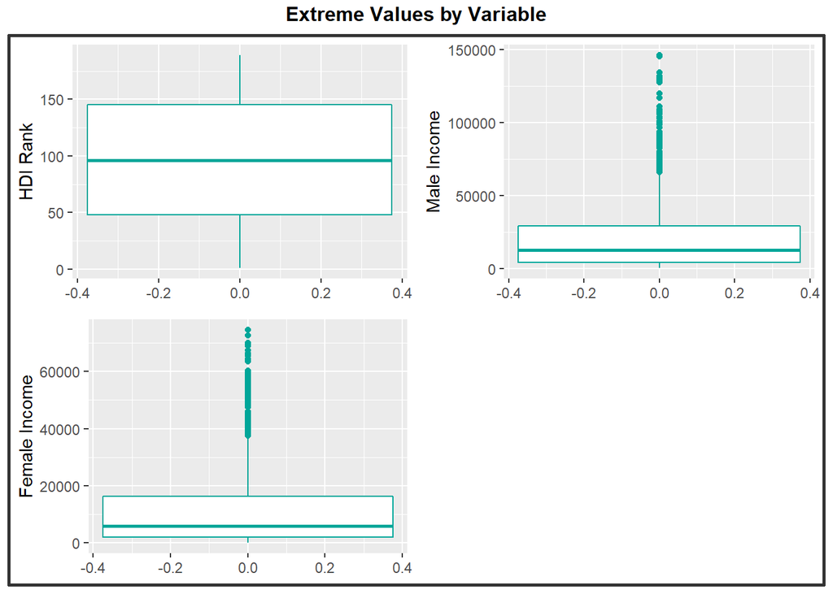

```r
annotate_figure(combined_box_plots, top = text_grob("Extreme Values by Variable", face = "bold"))
```

```r
# Explore the extreme values to ensure they make sense
all_income_hdi %>%
  filter(income_male > 100000 | income_female > 60000) %>%
  arrange(desc(income_female))
```

| year | country | hdi_rank_2018 | income_male | income_female | hdi | continent | perc_gender_pay_gap |
| --- | --- | --- | --- | --- | --- | --- | --- |
| 2.02e+03 | Singapore | 9 | 9.22e+04 | 7.46e+04 | 0.935 | Asia | 19.1 |
| 2.02e+03 | Singapore | 9 | 8.96e+04 | 7.26e+04 | 0.934 | Asia | 19.1 |
| 2.02e+03 | Singapore | 9 | 8.67e+04 | 7e+04 | 0.933 | Asia | 19.2 |
| 2.02e+03 | Singapore | 9 | 8.52e+04 | 6.94e+04 | 0.929 | Asia | 18.6 |
| 2.01e+03 | Singapore | 9 | 8.86e+04 | 6.89e+04 | 0.928 | Asia | 22.2 |
| 2.02e+03 | Brunei Darussalam | 43 | 8.98e+04 | 6.75e+04 | 0.843 | Asia | 24.9 |
| 2.01e+03 | Brunei Darussalam | 43 | 9.31e+04 | 6.63e+04 | 0.843 | Asia | 28.8 |
| 2.02e+03 | Brunei Darussalam | 43 | 8.74e+04 | 6.61e+04 | 0.843 | Asia | 24.3 |
| 2.01e+03 | Brunei Darussalam | 43 | 9.36e+04 | 6.59e+04 | 0.836 | Asia | 29.6 |
| 2.02e+03 | Brunei Darussalam | 43 | 8.61e+04 | 6.59e+04 | 0.845 | Asia | 23.4 |
| 2.02e+03 | Brunei Darussalam | 43 | 8.82e+04 | 6.59e+04 | 0.844 | Asia | 25.3 |
| 2.01e+03 | Singapore | 9 | 8.48e+04 | 6.58e+04 | 0.923 | Asia | 22.5 |
| 2.01e+03 | Brunei Darussalam | 43 | 9.1e+04 | 6.54e+04 | 0.844 | Asia | 28.1 |
| 2.01e+03 | Brunei Darussalam | 43 | 8.81e+04 | 6.45e+04 | 0.845 | Asia | 26.9 |
| 2.01e+03 | Singapore | 9 | 8.33e+04 | 6.4e+04 | 0.92 | Asia | 23.1 |
| 2.01e+03 | Singapore | 9 | 8.24e+04 | 6.36e+04 | 0.914 | Asia | 22.9 |
| 2.02e+03 | Norway | 1 | 7.57e+04 | 6.03e+04 | 0.954 | Europe | 20.4 |
| 2.02e+03 | Qatar | 41 | 1.31e+05 | 5.94e+04 | 0.847 | Asia | 54.8 |
| 2e+03 | Luxembourg | 21 | 1.11e+05 | 5.92e+04 | 0.88 | Europe | 46.7 |
| 2e+03 | Brunei Darussalam | 43 | 1.07e+05 | 5.88e+04 | 0.824 | Asia | 45.1 |
| 2.02e+03 | Qatar | 41 | 1.31e+05 | 5.87e+04 | 0.848 | Asia | 55.1 |
| 2.02e+03 | Qatar | 41 | 1.32e+05 | 5.78e+04 | 0.851 | Asia | 56.2 |
| 2.02e+03 | Qatar | 41 | 1.28e+05 | 5.72e+04 | 0.848 | Asia | 55.2 |
| 2e+03 | Brunei Darussalam | 43 | 1.07e+05 | 5.69e+04 | 0.805 | Asia | 47 |
| 2.01e+03 | Qatar | 41 | 1.29e+05 | 5.57e+04 | 0.854 | Asia | 56.9 |
| 2.01e+03 | Qatar | 41 | 1.3e+05 | 5.41e+04 | 0.857 | Asia | 58.3 |
| 2e+03 | Kuwait | 57 | 1.34e+05 | 5.35e+04 | 0.783 | Asia | 60.2 |
| 2e+03 | Brunei Darussalam | 43 | 1.17e+05 | 5.32e+04 | 0.791 | Asia | 54.6 |
| 2.01e+03 | Kuwait | 57 | 1.08e+05 | 5.29e+04 | 0.8 | Asia | 51 |
| 2e+03 | Luxembourg | 21 | 1.09e+05 | 5.21e+04 | 0.86 | Europe | 52.1 |
| 2.01e+03 | Kuwait | 57 | 1.03e+05 | 5.2e+04 | 0.798 | Asia | 49.5 |
| 2.01e+03 | Qatar | 41 | 1.31e+05 | 5.17e+04 | 0.85 | Asia | 60.5 |
| 2.01e+03 | Kuwait | 57 | 1.06e+05 | 5.06e+04 | 0.796 | Asia | 52.3 |
| 2e+03 | Kuwait | 57 | 1.29e+05 | 4.85e+04 | 0.748 | Asia | 62.3 |
| 2.01e+03 | Kuwait | 57 | 1.04e+05 | 4.83e+04 | 0.794 | Asia | 53.4 |
| 2.01e+03 | Qatar | 41 | 1.34e+05 | 4.82e+04 | 0.845 | Asia | 64.1 |
| 2e+03 | Qatar | 41 | 1.29e+05 | 4.57e+04 | 0.816 | Asia | 64.7 |
| 2e+03 | Kuwait | 57 | 1.09e+05 | 4.38e+04 | 0.786 | Asia | 59.9 |
| 2.01e+03 | Qatar | 41 | 1.3e+05 | 4.18e+04 | 0.834 | Asia | 67.9 |
| 2e+03 | Qatar | 41 | 1.29e+05 | 3.69e+04 | 0.838 | Asia | 71.5 |
| 2e+03 | United Arab Emirates | 35 | 1.46e+05 | 3.11e+04 | 0.782 | Asia | 78.7 |
| 2e+03 | United Arab Emirates | 35 | 1.2e+05 | 2.95e+04 | 0.809 | Asia | 75.4 |
| 2e+03 | United Arab Emirates | 35 | 1.46e+05 | 2.84e+04 | 0.764 | Asia | 80.6 |
| 2e+03 | Qatar | 41 | 1.01e+05 | 2.79e+04 | 0.789 | Asia | 72.4 |

```r
# visualise the dependent variable
```

As expected the middle east mainly accounts for the extreme values in male income, whilst interestingly enough Singapore and Brunei account for the majority of extreme values in female incomes. Nevertheless, following research we can conclude that there are no data entry issues with our dataset

## Data Exploration

```r
# Find the top 10 highest paygap and the lower 10 paygap for 2018
top_10 <- all_income_hdi %>%
  filter(year == 2018) %>%
  top_n(10, perc_gender_pay_gap)
low_10 <- all_income_hdi %>%
  filter(year == 2018) %>%
  top_n(-10, perc_gender_pay_gap)
# Find average pay gap in 2018 by continent
by_continent <- all_income_hdi %>%
  filter(year == 2018) %>%
  group_by(continent) %>%
  summarise(avg_perc_paygap = mean(perc_gender_pay_gap),
            avg_hdi = mean(hdi)) %>%
  arrange(desc(avg_hdi))
# Find the number of countries with a paygap greater than 50% by continent in 1995 vs 2018
change <- all_income_hdi %>%
  filter(year %in% c(1995, 2018)) %>%
  group_by(continent, year) %>%
  summarise(count = count(perc_gender_pay_gap > 50))
## Things are getting better!!!
```

## Correlation Matrix

We make a correlation matrix to observe the interaction between variables and specially focus on analysiing the relation of various factors with the percentage gender pay gap:

```r
#create correlation matrix for variables with data type "double"
correlation_matrix <- all_income_hdi %>%
  summarise(
         year,
         hdi,
         income_male,
         income_female,
         continent,
         perc_gender_pay_gap)
#have a look on the correlation matrix data
glimpse(correlation_matrix)
```

```
## Rows: 2,112
## Columns: 6
## $ year                <dbl> 1995, 1995, 1995, 1995, 1995, 1995, 1995, 1995,...
## $ hdi                 <dbl> 0.327, 0.629, 0.602, NA, 0.731, 0.604, 0.883, 0...
## $ income_male         <dbl> 1756, 5338, 15808, 3294, 18633, 2827, 38073, 44...
## $ income_female       <dbl> 692, 3032, 1820, 2424, 9107, 1574, 21060, 23695...
## $ continent           <fct> Asia, Europe, Africa, Africa, Americas, Asia, O...
## $ perc_gender_pay_gap <dbl> 60.59226, 43.19970, 88.48684, 26.41166, 51.1243...
```

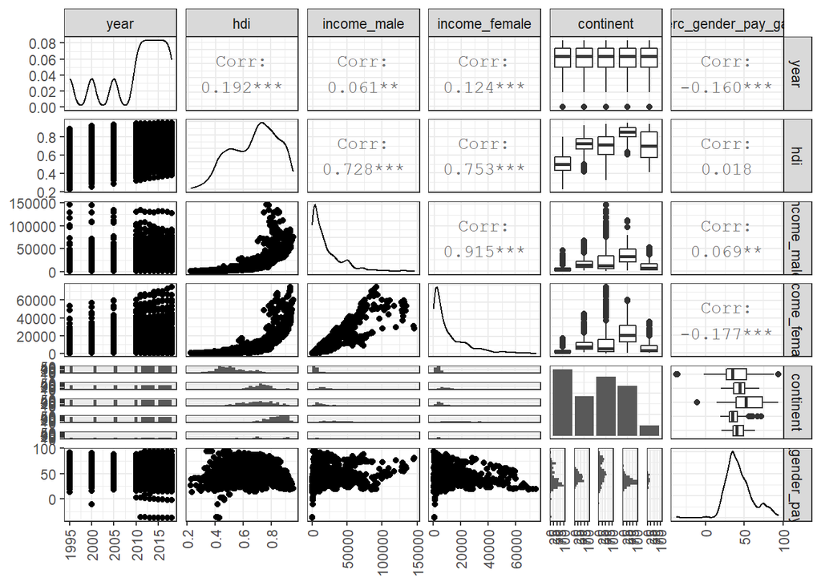

```r
#show the correlations
ggpairs(correlation_matrix, columns=1:6,
    upper=list(continuous='cor'),
    lower=list(continuous = 'points'),
    diag=list(continuous='density'),
    axisLabels='show') +
    theme_bw()+
    theme(axis.text.x = element_text(angle = 90, vjust = 0.5, hjust=1))
```

### Hypothesis Testing

We build confidence intervals for male and female income and see if the difference is significant at a 95% confidence interval using hypothesis testing where our null hypothesis is: There is no difference between male and female income.

```r
# create groups for our top and bottom 3 countries in Europe
top_3 <- c("Netherlands","Switzerland","Denmark")
bottom3 <- c("Hungary","Poland","Latvia")
our_6 <- c("Netherlands","Switzerland","Denmark","Hungary","Poland","Latvia")

# filter data for our 6 countries
filtered <- all_income_hdi %>%
  subset(all_income_hdi$country %in% our_6) %>%
  rename(female= income_female) %>%
  rename(male = income_male) %>%
  pivot_longer(4:5, names_to = "Gender", values_to = "Income")

#filtered

# build confidence interval
filtered %>%
  group_by(Gender) %>%
  filter(!is.na(Income)) %>%
  summarise(mean_income = mean(Income, na.rm = TRUE),
            sd_income = sd(Income, na.rm=TRUE),
            count = n(),
            se_income = sd_income/sqrt(count),
            t_critical = qt(0.975, count-1),
            margin_of_error = t_critical * se_income,
            lower = mean_income - t_critical * se_income,
            upper = mean_income + t_critical * se_income
            )
```

| Gender | mean_income | sd_income | count | se_income | t_critical | margin_of_error | lower | upper |
| --- | --- | --- | --- | --- | --- | --- | --- | --- |
| female | 2.81e+04 | 1.25e+04 | 72 | 1.47e+03 | 1.99 | 2.94e+03 | 2.52e+04 | 3.11e+04 |
| male | 4.25e+04 | 1.79e+04 | 72 | 2.11e+03 | 1.99 | 4.2e+03 | 3.83e+04 | 4.67e+04 |

```r
# perform hypothesis test
t.test(Income ~ Gender, data = filtered)
```

```
##
##  Welch Two Sample t-test
##
## data:  Income by Gender
## t = -5.5861, df = 126.97, p-value = 1.349e-07
## alternative hypothesis: true difference in means is not equal to 0
## 95 percent confidence interval:
##  -19444.108  -9271.837
## sample estimates:
## mean in group female   mean in group male
##             28149.99             42507.96
```

We see that the confidence intervals don’t overlap and clearly, we can reject the null hypothesis since the t score is greater than 2 and say with 95% confidence that the difference with respect to gender is significant.

Next, we check if the difference in the percentage gender gap is considerably different for the top 3 compared to the bottom 3 countries in Europe. Once again, we can say with 95% confidence that the difference is significant.

```r
by_country <- filtered %>%
  mutate(top_or_bottom = ifelse(country %in% top_3, 'top', 'bottom'))

by_country %>%
  group_by(top_or_bottom) %>%
  filter(!is.na(perc_gender_pay_gap)) %>%
  summarise(mean_gap = mean(perc_gender_pay_gap, na.rm = TRUE),
            sd_gap = sd(perc_gender_pay_gap, na.rm=TRUE),
            count = n(),
            se_gap = sd_gap/sqrt(count),
            t_critical = qt(0.975, count-1),
            margin_of_error = t_critical * se_gap,
            lower = mean_gap - t_critical * se_gap,
            upper = mean_gap + t_critical * se_gap
            )
```

| top_or_bottom | mean_gap | sd_gap | count | se_gap | t_critical | margin_of_error | lower | upper |
| --- | --- | --- | --- | --- | --- | --- | --- | --- |
| bottom | 35.8 | 3.67 | 72 | 0.433 | 1.99 | 0.863 | 34.9 | 36.7 |
| top | 33.1 | 5.36 | 72 | 0.632 | 1.99 | 1.26 | 31.8 | 34.3 |

```r
t.test(perc_gender_pay_gap ~ top_or_bottom, data = by_country)
```

```
##
##  Welch Two Sample t-test
##
## data:  perc_gender_pay_gap by top_or_bottom
## t = 3.5719, df = 125.61, p-value = 0.0005033
## alternative hypothesis: true difference in means is not equal to 0
## 95 percent confidence interval:
##  1.220021 4.251555
## sample estimates:
## mean in group bottom    mean in group top
##             35.81005             33.07426
```

### Regression Analysis

We begin building a linear regression model for the gender pay gap. Work is in progress as we try to find and merge more factors that may have an effect on our dependent variable to make a more meaningful model.

Our first models are shown below:

```r
##makes first 2 models using instructions from Kostis
model1 <- lm(perc_gender_pay_gap ~
               hdi,
             data = all_income_hdi)
model2 <- lm(perc_gender_pay_gap ~
               hdi +
             year,
             data = all_income_hdi)
#model 3 adds the factor variable continent
model3 <- lm(perc_gender_pay_gap ~
               hdi +
             year +
             continent,
             data = all_income_hdi)
huxreg(model1, model2, model3)
```

|  | (1) | (2) | (3) |
| --- | --- | --- | --- |
| (Intercept) | 42.218 *** | 952.259 *** | 1069.377 *** |
|  | (1.692) | (120.006) | (113.562) |
| hdi | 1.962 | 5.513 * | 17.304 *** |
|  | (2.422) | (2.435) | (3.481) |
| year |  | -0.454 *** | -0.516 *** |
|  |  | (0.060) | (0.057) |
| continentAmericas |  |  | 0.093 |
|  |  |  | (1.299) |
| continentAsia |  |  | 10.843 *** |
|  |  |  | (1.155) |
| continentEurope |  |  | -9.607 *** |
|  |  |  | (1.518) |
| continentOceania |  |  | -2.484 |
|  |  |  | (1.902) |
| N | 2069 | 2069 | 2069 |
| R2 | 0.000 | 0.027 | 0.180 |
| logLik | -8882.998 | -8854.592 | -8678.024 |
| AIC | 17771.997 | 17717.183 | 17372.048 |
| *** p < 0.001; ** p < 0.01; * p < 0.05. |  |  |  |

```r
str(all_income_hdi)
```

```
## 'data.frame':    2112 obs. of  8 variables:
##  $ year               : num  1995 1995 1995 1995 1995 ...
##  $ country            : chr  "Afghanistan" "Albania" "Algeria" "Angola" ...
##  $ hdi_rank_2018      : num  170 69 82 149 48 81 6 20 87 60 ...
##  $ income_male        : num  1756 5338 15808 3294 18633 ...
##  $ income_female      : num  692 3032 1820 2424 9107 ...
##  $ hdi                : num  0.327 0.629 0.602 NA 0.731 0.604 0.883 0.817 0.612 NA ...
##  $ continent          : Factor w/ 5 levels "Africa","Americas",..: 3 4 1 1 2 3 5 4 3 2 ...
##  $ perc_gender_pay_gap: num  60.6 43.2 88.5 26.4 51.1 ...
```

```r
## still trying to find more variables to utilise to make a more meaningful model
```